# GSS Analysis Report

Qiyu Huang& Yuhan Zhu

10/19/2020

## Abstract

We are going to take a analysis on th Canadian General Social Survey. We have used logistic regression and linear regression to see relationships. Deetails are shown later in the discussion part.

## Introduction

We want to find if people are older, will they have more kids, more relationships, and have early kids when they are young? We also want to find if the income level is related with gender, with total number of children, and with satisfaction of their lives. Will the family be richer if they have more kids or poorer is what we want to find out as well. ## Data

# Data cleaning Part

### importing raw data

raw_data <- read_csv(“/cloud/project/AAGe4G0U.csv”) dict <- read_lines(“gss_dict.txt”, skip = 18) labels_raw <- read_file(“gss_labels.txt”)

### set up dictionary

variable_descriptions <- as_tibble(dict) %>% filter(value!=“}”) %>% mutate(value = str_replace(value, ".+%[0-9].*f[ ]{2,}“,”“)) %>% mutate(value = str_remove_all(value,”"")) %>% rename(variable_description = value) %>% bind_cols(tibble(variable_name = colnames(raw_data)[-1]))

### variable names and values

labels_raw_tibble <- as_tibble(str_split(labels_raw, “;”)[[1]]) %>% filter(row_number()!=1) %>% mutate(value = str_remove(value, “define”)) %>% mutate(value = str_replace(value, “[ ]{2,}”, “XXX”)) %>% mutate(splits = str_split(value, “XXX”)) %>% rowwise() %>% mutate(variable_name = splits[1], cases = splits[2]) %>% mutate(cases = str_replace_all(cases, “”, "")) %>% select(variable_name, cases) %>% drop_na()

### variable name

labels_raw_tibble <- labels_raw_tibble %>% mutate(splits = str_split(cases, “[ ]{0,}"[ ]{0,}”))

### creating a function

add_cw_text <- function(x, y){ if(!is.na(as.numeric(x))){ x_new <- paste0(y, “==”, x,“~”) } else{ x_new <- paste0(“"”,x,“",”) } return(x_new) } ### Another function cw_statements <- labels_raw_tibble %>% rowwise() %>% mutate(splits_with_cw_text = list(modify(splits, add_cw_text, y = variable_name))) %>% mutate(cw_statement = paste(splits_with_cw_text, collapse = "“)) %>% mutate(cw_statement = paste0(”case_when(“, cw_statement,”TRUE~"NA")“)) %>% mutate(cw_statement = str_replace(cw_statement,”,"",“,”,")) %>% select(variable_name, cw_statement)

### Do some final cleans of this function

cw_statements <- cw_statements %>% mutate(variable_name = str_remove_all(variable_name, “\r”)) %>% mutate(cw_statement = str_remove_all(cw_statement, “\r”))

### Apply that dictionary to the raw data

gss <- raw_data %>% select(CASEID, agedc, achd_1c, achdmpl, totchdc, acu0c, agema1c, achb1c, rsh_131a, arretwk, slm_01, sex, brthcan, brthfcan, brthmcan, brthmacr, brthprvc, yrarri, prv, region, luc_rst, marstat, amb_01, vismin, alndimmg, bpr_16, bpr_19, ehg3_01b, odr_10, livarr12, dwelc, hsdsizec, brthpcan, brtpprvc, visminpr, rsh_125a, eop_200, uhw_16gr, lmam_01, acmpryr, srh_110, srh_115, religflg, rlr_110, lanhome, lan_01, famincg2, ttlincg2, noc1610, cc_20_1, cc_30_1, ccmoc1c, cor_031, cor_041, cu0rnkc, pr_cl, chh0014c, nochricc, grndpa, gparliv, evermar, ma0_220, nmarevrc, ree_02, rsh_131b, rto_101, rto_110, rto_120, rtw_300, sts_410, csp_105, csp_110a, csp_110b, csp_110c, csp_110d, csp_160, fi_110) %>% mutate_at(vars(agedc:fi_110), .funs = funs(ifelse(.>=96, NA, .))) %>% mutate_at(.vars = vars(sex:fi_110), .funs = funs(eval(parse(text = cw_statements %>% filter(variable_name==deparse(substitute(.))) %>% select(cw_statement) %>% pull()))))

### Change the attributes name

gss <- gss %>% clean_names() %>% rename(age = agedc, age_first_child = achd_1c, age_youngest_child_under_6 = achdmpl, total_children = totchdc, age_start_relationship = acu0c, age_at_first_marriage = agema1c, age_at_first_birth = achb1c, distance_between_houses = rsh_131a, age_youngest_child_returned_work = arretwk, feelings_life = slm_01, sex = sex, place_birth_canada = brthcan, place_birth_father = brthfcan, place_birth_mother = brthmcan, place_birth_macro_region = brthmacr, place_birth_province = brthprvc, year_arrived_canada = yrarri, province = prv, region = region, pop_center = luc_rst, marital_status = marstat, aboriginal = amb_01, vis_minority = vismin, age_immigration = alndimmg, landed_immigrant = bpr_16, citizenship_status = bpr_19, education = ehg3_01b, own_rent = odr_10, living_arrangement = livarr12, hh_type = dwelc, hh_size = hsdsizec, partner_birth_country = brthpcan, partner_birth_province = brtpprvc, partner_vis_minority = visminpr, partner_sex = rsh_125a, partner_education = eop_200, average_hours_worked = uhw_16gr, worked_last_week = lmam_01, partner_main_activity = acmpryr, self_rated_health = srh_110, self_rated_mental_health = srh_115, religion_has_affiliation = religflg, regilion_importance = rlr_110, language_home = lanhome, language_knowledge = lan_01, income_family = famincg2, income_respondent = ttlincg2, occupation = noc1610, childcare_regular = cc_20_1, childcare_type = cc_30_1, childcare_monthly_cost = ccmoc1c, ever_fathered_child = cor_031, ever_given_birth = cor_041, number_of_current_union = cu0rnkc, lives_with_partner = pr_cl, children_in_household = chh0014c, number_total_children_intention = nochricc, has_grandchildren = grndpa, grandparents_still_living = gparliv, ever_married = evermar, current_marriage_is_first = ma0_220, number_marriages = nmarevrc, religion_participation = ree_02, partner_location_residence = rsh_131b, full_part_time_work = rto_101, time_off_work_birth = rto_110, reason_no_time_off_birth = rto_120, returned_same_job = rtw_300, satisfied_time_children = sts_410, provide_or_receive_fin_supp = csp_105, fin_supp_child_supp = csp_110a, fin_supp_child_exp = csp_110b, fin_supp_lump = csp_110c, fin_supp_other = csp_110d, fin_supp_agreement = csp_160, future_children_intention = fi_110)

### save to a new csv file and finish cleaning

write_csv(gss, “gss.csv”)

## Model

I have used ggplot, histogram, logistic regression, linear regression to analaysis these datasets.

This is the mathmetical notation for linear regression :y = β0 + β1x + e, where β0 is the intercept, there could be β2,β3 and so on. Y must be numerical. Predictors can be both numerical and categorical. In this case, I have picked some numerical variables as predictors and age as Y.

This is the mathmetical notation for logistic regression : log(p/(1-p)) = β0 + β1x,where β0 is the intercept, there could be β2,β3 and so on. P is the probability of an event that is going to occur. β1 is a coefficient represents changes in log adds for every one unit increase in x. Y can either be 1 or 0.

## Results

```
##      caseid           age        age_first_child age_youngest_child_under_6
##  Min.   :    1   Min.   :15.00   Min.   : 0.00   Min.   :0.000
##  1st Qu.: 5151   1st Qu.:37.30   1st Qu.:15.00   1st Qu.:1.000
##  Median :10302   Median :54.20   Median :32.00   Median :2.000
##  Mean   :10302   Mean   :52.19   Mean   :30.57   Mean   :2.412
##  3rd Qu.:15452   3rd Qu.:66.78   3rd Qu.:44.00   3rd Qu.:4.000
##  Max.   :20602   Max.   :80.00   Max.   :60.00   Max.   :5.000
##                                  NA's   :6835    NA's   :18488
##  total_children  age_start_relationship age_at_first_marriage
##  Min.   :0.000   Min.   :18.00          Min.   :15.0
##  1st Qu.:0.000   1st Qu.:25.00          1st Qu.:20.5
##  Median :2.000   Median :30.50          Median :22.8
##  Mean   :1.679   Mean   :33.63          Mean   :24.1
##  3rd Qu.:3.000   3rd Qu.:40.62          3rd Qu.:26.4
##  Max.   :7.000   Max.   :60.00          Max.   :50.0
##  NA's   :19      NA's   :18566          NA's   :15248
##  age_at_first_birth distance_between_houses age_youngest_child_returned_work
##  Min.   :18.00      Min.   : 0.00           Min.   : 0.200
##  1st Qu.:22.80      1st Qu.: 4.00           1st Qu.: 0.500
##  Median :26.40      Median :10.00           Median : 6.000
##  Mean   :26.86      Mean   :17.13           Mean   : 6.589
##  3rd Qu.:30.30      3rd Qu.:24.75           3rd Qu.:12.000
##  Max.   :45.00      Max.   :90.00           Max.   :48.000
##  NA's   :7865       NA's   :19476           NA's   :19466
##  feelings_life        sex            place_birth_canada place_birth_father
##  Min.   : 0.000   Length:20602       Length:20602       Length:20602
##  1st Qu.: 7.000   Class :character   Class :character   Class :character
##  Median : 8.000   Mode  :character   Mode  :character   Mode  :character
##  Mean   : 8.094
##  3rd Qu.: 9.000
##  Max.   :10.000
##  NA's   :271
##  place_birth_mother place_birth_macro_region place_birth_province
##  Length:20602       Length:20602             Length:20602
##  Class :character   Class :character         Class :character
##  Mode  :character   Mode  :character         Mode  :character
##
##
##
##
```

[output cut: 137 more lines]

```
##  Min.   :0.000   Min.   :0.000   Length:20602       Length:20602
##  1st Qu.:0.000   1st Qu.:0.000   Class :character   Class :character
##  Median :0.000   Median :0.000   Mode  :character   Mode  :character
##  Mean   :0.055   Mean   :0.055
##  3rd Qu.:0.000   3rd Qu.:0.000
##  Max.   :1.000   Max.   :1.000
##  NA's   :20057   NA's   :20057
##     is_male       main_activity    age_diff         number_total_children_known
##  Min.   :0.0000   Mode:logical   Length:20602       Min.   :0.0000
##  1st Qu.:0.0000   NA's:20602     Class :character   1st Qu.:0.0000
##  Median :0.0000                  Mode  :character   Median :0.0000
##  Mean   :0.4562                                     Mean   :0.4123
##  3rd Qu.:1.0000                                     3rd Qu.:1.0000
##  Max.   :1.0000                                     Max.   :1.0000
##
```

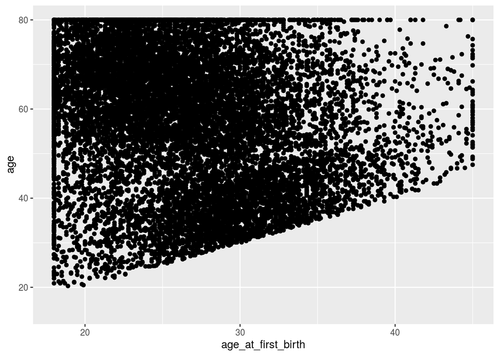

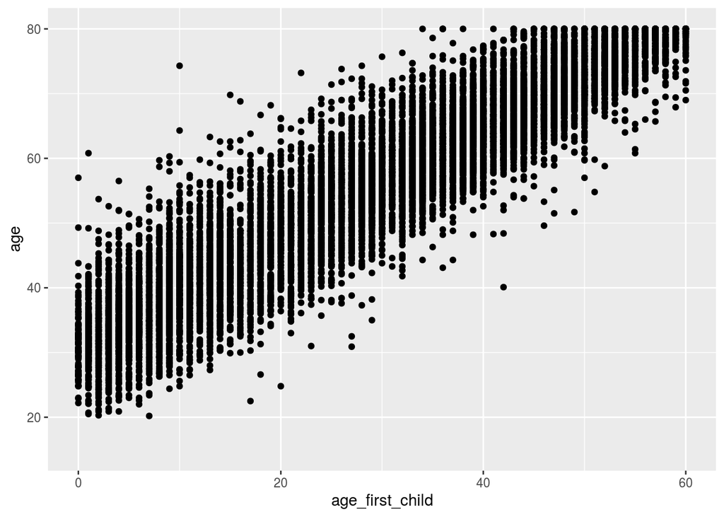

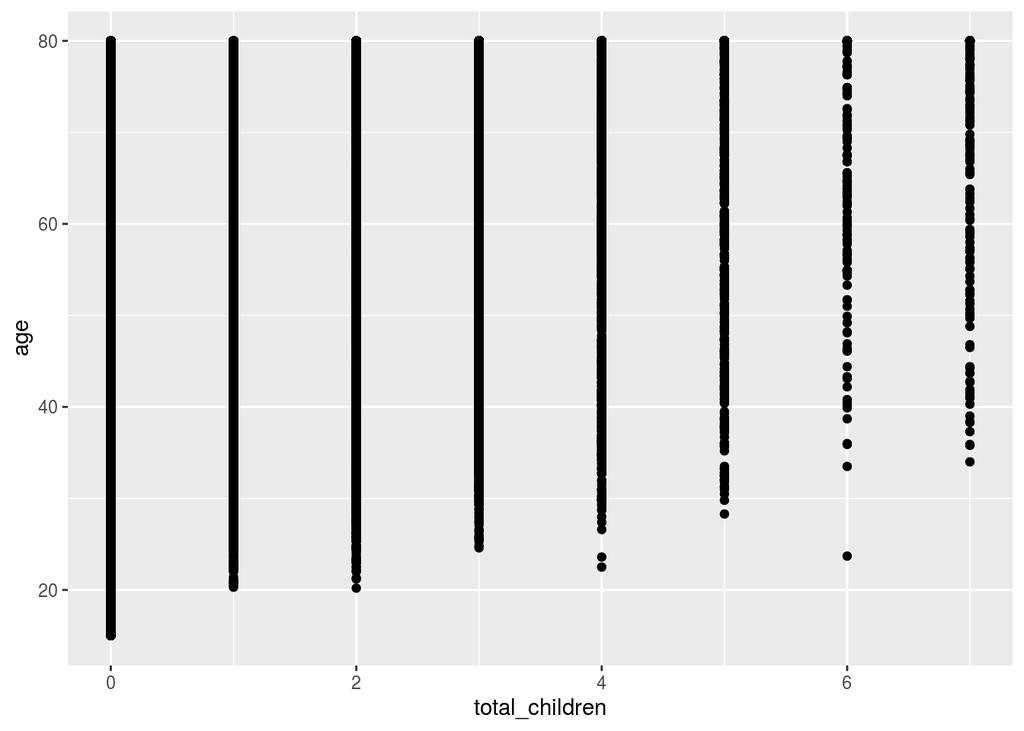

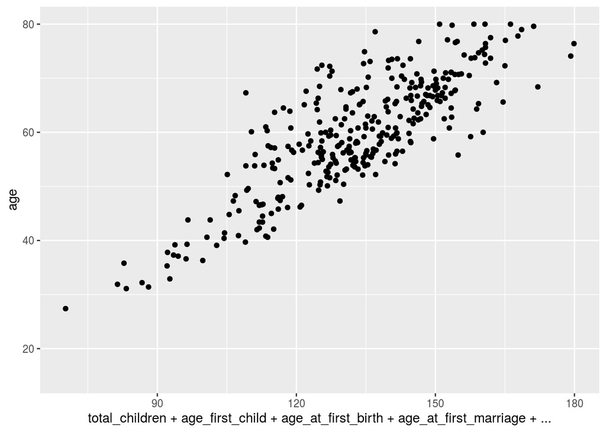

## linear regression

```
##
## Call:
## lm(formula = age ~ total_children + age_first_child + age_at_first_birth +
##     age_at_first_marriage + age_start_relationship, data = gss)
##
## Residuals:
##     Min      1Q  Median      3Q     Max
## -3.7577 -0.3441 -0.0071  0.2994 13.8028
##
## Coefficients:
##                         Estimate Std. Error t value Pr(>|t|)
## (Intercept)            -0.541116   0.470578  -1.150   0.2510
## total_children         -0.010812   0.040020  -0.270   0.7872
## age_first_child         0.985121   0.005762 170.956   <2e-16 ***
## age_at_first_birth      1.018111   0.013588  74.930   <2e-16 ***
## age_at_first_marriage  -0.005123   0.012937  -0.396   0.6924
## age_start_relationship  0.015489   0.006343   2.442   0.0151 *
## ---
## Signif. codes:  0 '***' 0.001 '**' 0.01 '*' 0.05 '.' 0.1 ' ' 1
##
## Residual standard error: 0.9223 on 324 degrees of freedom
##   (20272 observations deleted due to missingness)
## Multiple R-squared:  0.9925, Adjusted R-squared:  0.9924
## F-statistic:  8565 on 5 and 324 DF,  p-value: < 2.2e-16
```

```
##
## Call:
## lm(formula = age ~ total_children + income_family, data = gss)
##
## Residuals:
##     Min      1Q  Median      3Q     Max
## -55.970 -12.472   1.057  12.067  41.785
##
## Coefficients:
##                                 Estimate Std. Error t value Pr(>|t|)
## (Intercept)                     39.75129    0.35396 112.304  < 2e-16 ***
## total_children                   5.30882    0.07226  73.473  < 2e-16 ***
## income_family$125,000 and more  -1.53603    0.40167  -3.824 0.000132 ***
## income_family$25,000 to $49,999  8.06564    0.40688  19.823  < 2e-16 ***
## income_family$50,000 to $74,999  5.46642    0.41852  13.061  < 2e-16 ***
## income_family$75,000 to $99,999  1.89703    0.43850   4.326 1.52e-05 ***
## income_familyLess than $25,000   6.86210    0.44340  15.476  < 2e-16 ***
## ---
## Signif. codes:  0 '***' 0.001 '**' 0.01 '*' 0.05 '.' 0.1 ' ' 1
##
## Residual standard error: 15.44 on 20576 degrees of freedom
##   (19 observations deleted due to missingness)
## Multiple R-squared:  0.2438, Adjusted R-squared:  0.2436
## F-statistic:  1106 on 6 and 20576 DF,  p-value: < 2.2e-16
```

## Logistic Regression

| caseid | age | age_first_child | age_youngest_child_under_6 | total_children | age_start_relationship | age_at_first_marriage | age_at_first_birth | distance_between_houses | age_youngest_child_returned_work | feelings_life | sex | place_birth_canada | place_birth_father | place_birth_mother | place_birth_macro_region | place_birth_province | year_arrived_canada | province | region | pop_center | marital_status | aboriginal | vis_minority | age_immigration | landed_immigrant | citizenship_status | education | own_rent | living_arrangement | … |
| --- | --- | --- | --- | --- | --- | --- | --- | --- | --- | --- | --- | --- | --- | --- | --- | --- | --- | --- | --- | --- | --- | --- | --- | --- | --- | --- | --- | --- | --- | --- |
| 1 | 52.7 | 27 | NA | 1 | NA | NA | 25.9 | 30 | NA | 8 | 1 | Born in Canada | Born in Canada | Born in Canada | NA | Quebec | NA | Quebec | Quebec | Larger urban population centres (CMA/CA) | Single, never married | No | Not a visible minority | NA | NA | By birth | High school diploma or a high school equivalency certificate | Owned by you or a member of this household, even if it i... | Alone | … |
| 2 | 51.1 | 33 | NA | 5 | NA | NA | NA | NA | NA | 10 | 0 | Born in Canada | Born in Canada | Born in Canada | NA | Ontario | NA | Manitoba | Prairie region | Larger urban population centres (CMA/CA) | Married | No | Not a visible minority | NA | NA | By birth | Trade certificate or diploma | Owned by you or a member of this household, even if it i... | Spouse only | … |
| 3 | 63.6 | 40 | NA | 5 | NA | NA | 23.2 | NA | NA | 8 | 1 | Born in Canada | Born in Canada | Born in Canada | NA | Ontario | NA | Ontario | Ontario | Rural areas and small population centres (non CMA/CA) | Married | No | Not a visible minority | NA | NA | By birth | Bachelor's degree (e.g. B.A., B.Sc., LL.B.) | Owned by you or a member of this household, even if it i... | Spouse only | … |
| 4 | 80.0 | 56 | NA | 1 | NA | NA | 27.3 | NA | NA | 10 | 1 | Born in Canada | Born outside Canada | Born outside Canada | NA | Alberta | NA | Alberta | Prairie region | Larger urban population centres (CMA/CA) | Married | No | Not a visible minority | NA | NA | By birth | High school diploma or a high school equivalency certificate | Owned by you or a member of this household, even if it i... | Spouse only | … |
| 5 | 28.0 | NA | NA | 0 | 25.3 | NA | NA | NA | NA | 8 | 0 | Born in Canada | Born in Canada | Born in Canada | NA | Quebec | NA | Quebec | Quebec | Larger urban population centres (CMA/CA) | Living common-law | No | Not a visible minority | NA | NA | By birth | College, CEGEP or other non-university certificate or di... | Rented, even if no cash rent is paid | Spouse only | … |
| 6 | 63.0 | 37 | NA | 2 | NA | NA | 25.8 | NA | NA | 9 | 1 | Born in Canada | Born in Canada | Born in Canada | NA | Quebec | NA | Quebec | Quebec | Larger urban population centres (CMA/CA) | Married | No | Not a visible minority | NA | NA | By birth | High school diploma or a high school equivalency certificate | Owned by you or a member of this household, even if it i... | Spouse only | … |

[output not shown]

```
##
##    1    2    3    4    5    6
## 2775 4345 3696 2921 2158 4707
```

[output not shown]

[output cut: 62 more lines]

[output not shown]

|  | caseid | age | age_first_child | age_youngest_child_under_6 | total_children | age_start_relationship | age_at_first_marriage | age_at_first_birth | distance_between_houses | age_youngest_child_returned_work | feelings_life | sex | place_birth_canada | place_birth_father | place_birth_mother | place_birth_macro_region | place_birth_province | year_arrived_canada | province | region | pop_center | marital_status | aboriginal | vis_minority | age_immigration | landed_immigrant | citizenship_status | education | own_rent | … |
| --- | --- | --- | --- | --- | --- | --- | --- | --- | --- | --- | --- | --- | --- | --- | --- | --- | --- | --- | --- | --- | --- | --- | --- | --- | --- | --- | --- | --- | --- | --- |
| 1 | 1 | 52.7 | 27 | NA | 1 | NA | NA | 25.9 | 30 | NA | 8 | 1 | NA | NA | NA | NA | NA | NA | NA | NA | NA | NA | NA | NA | NA | NA | NA | NA | NA | … |
| 2 | 2 | 51.1 | 33 | NA | 5 | NA | NA | NA | NA | NA | 10 | 0 | NA | NA | NA | NA | NA | NA | NA | NA | NA | NA | NA | NA | NA | NA | NA | NA | NA | … |
| 3 | 3 | 63.6 | 40 | NA | 5 | NA | NA | 23.2 | NA | NA | 8 | 1 | NA | NA | NA | NA | NA | NA | NA | NA | NA | NA | NA | NA | NA | NA | NA | NA | NA | … |
| 4 | 4 | 80.0 | 56 | NA | 1 | NA | NA | 27.3 | NA | NA | 10 | 1 | NA | NA | NA | NA | NA | NA | NA | NA | NA | NA | NA | NA | NA | NA | NA | NA | NA | … |
| 5 | 5 | 28.0 | NA | NA | 0 | 25.3 | NA | NA | NA | NA | 8 | 0 | NA | NA | NA | NA | NA | NA | NA | NA | NA | NA | NA | NA | NA | NA | NA | NA | NA | … |
| 6 | 6 | 63.0 | 37 | NA | 2 | NA | NA | 25.8 | NA | NA | 9 | 1 | NA | NA | NA | NA | NA | NA | NA | NA | NA | NA | NA | NA | NA | NA | NA | NA | NA | … |

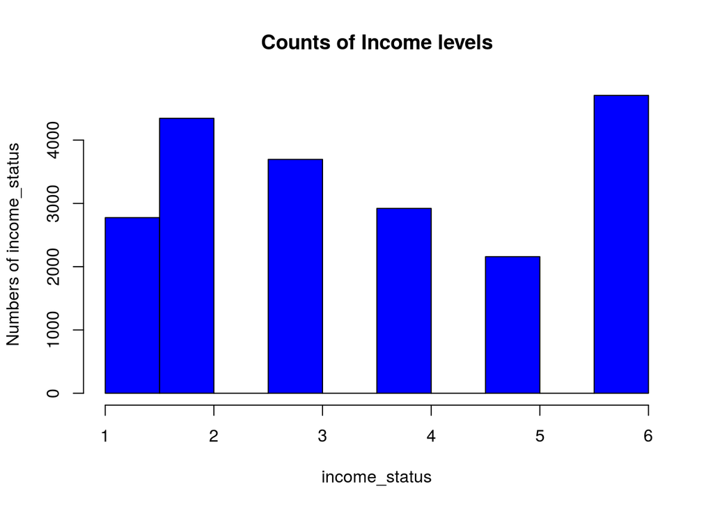

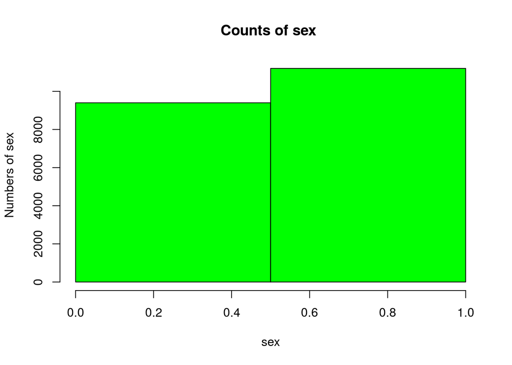

## Standard Logistic Regression

```
##
## Call:
## glm(formula = sex ~ age + age_first_child + total_children +
##     feelings_life + as.factor(income_status), family = "binomial",
##     data = gss_numeric)
##
## Deviance Residuals:
##     Min       1Q   Median       3Q      Max
## -2.4244  -1.1885   0.7674   1.0340   1.9379
##
## Coefficients:
##                            Estimate Std. Error z value Pr(>|z|)
## (Intercept)                3.786023   0.170562  22.197  < 2e-16 ***
## age                       -0.097040   0.003906 -24.841  < 2e-16 ***
## age_first_child            0.090983   0.003602  25.260  < 2e-16 ***
## total_children            -0.189921   0.017017 -11.161  < 2e-16 ***
## feelings_life              0.025987   0.011501   2.260   0.0238 *
## as.factor(income_status)2 -0.293959   0.070921  -4.145 3.40e-05 ***
## as.factor(income_status)3 -0.582232   0.072268  -8.057 7.85e-16 ***
## as.factor(income_status)4 -0.632205   0.075822  -8.338  < 2e-16 ***
## as.factor(income_status)5 -0.733849   0.080806  -9.082  < 2e-16 ***
## as.factor(income_status)6 -0.633354   0.071529  -8.855  < 2e-16 ***
## ---
## Signif. codes:  0 '***' 0.001 '**' 0.01 '*' 0.05 '.' 0.1 ' ' 1
##
## (Dispersion parameter for binomial family taken to be 1)
##
##     Null deviance: 18560  on 13584  degrees of freedom
## Residual deviance: 17585  on 13575  degrees of freedom
##   (7017 observations deleted due to missingness)
## AIC: 17605
##
## Number of Fisher Scoring iterations: 4
```

## Survey Estimation for Logistic Regression

install.packages(“survey”) library(survey)

## Using the Survey Library

```
##
## Call:
## svyglm(formula = sex ~ age + age_first_child + total_children +
##     feelings_life + as.factor(income_status), design = a, family = "binomial")
##
## Survey design:
## svydesign(id = ~1, data = gss_numeric, fpc = b)
##
## Coefficients:
##                            Estimate Std. Error t value Pr(>|t|)
## (Intercept)                3.786023   0.140641  26.920  < 2e-16 ***
## age                       -0.097040   0.003257 -29.794  < 2e-16 ***
## age_first_child            0.090983   0.002992  30.410  < 2e-16 ***
## total_children            -0.189921   0.013716 -13.847  < 2e-16 ***
## feelings_life              0.025987   0.009315   2.790  0.00528 **
## as.factor(income_status)2 -0.293959   0.056767  -5.178 2.27e-07 ***
## as.factor(income_status)3 -0.582232   0.058178 -10.008  < 2e-16 ***
## as.factor(income_status)4 -0.632205   0.061268 -10.319  < 2e-16 ***
## as.factor(income_status)5 -0.733849   0.065778 -11.157  < 2e-16 ***
## as.factor(income_status)6 -0.633354   0.058028 -10.915  < 2e-16 ***
## ---
## Signif. codes:  0 '***' 0.001 '**' 0.01 '*' 0.05 '.' 0.1 ' ' 1
##
## (Dispersion parameter for binomial family taken to be 1.002454)
##
## Number of Fisher Scoring iterations: 4
```

## Discussion

By using summary, we can see the details of each variable.

Then we created several ggplots to determine relationships between factors.

There is a positive linear relationship between age_first_child and age.

Then we run linear regression since we foud some relationship.

The function will be Y = (-0.54 + -0.01* total_children + 0.99* age_first_child +1.02* age_at_first_birth-0.01* age_at_first_marriage+0.02*age_start_relationship)

Since there are many missing values that has been removed, about 20272 rows. So we recreated a linear regression, this time, I added categorical variables income_family to test if age and income are related.

The function will be Y = 39.75 + 5.31* total_children - 1.54* ‘125,000 and more’ + 8.07* ‘25,000 to $49,999’ + 5.47*‘50,000 to $74,999’ + 1.90* ‘75,000 to $99,999’ + 6.86*‘Less than $25,000’

In order to generate logistic regression. We created a binary variable as our Y value which is sex. We set female = 1 and male = 0.

Then we sepertaed the income_family by 1,2,3,4,5,6 levels. ‘1’ is the poorest family and ‘6’ is richest family as the rank.

Since logistic regression Y is a binary.Current Y value is a character. So we changed GSS file to numerical and named it gss_numeric.

We created a histogram to show the income status from 1 through 6. According to the histogram, there are many income_family that have income over $125,000 and between $25,000 to $49,000.

We also created a histogram of female and male. According to the histogram, there are more females than males in the dataset.

The logistic regression function we got is Y = 3.79-0.097* age+0.091* age_first_child-0.19* total_children+0.026*feelings_life-0.294x2-0.58x3-0.63x4-0.73x5-0.63x6 There is about 1000 difference between null deviance and residual deviance, the larger the difference is, the better the model is.

## Weaknesses

There are many missing values even after data cleaning. If by removing all the NAs,there will be 0 rows left. So in order to run some analysis, we have to obtain some missing values. But due to this is a questionaire, it’s hard to obtain perfect answers. There are too many columns, factors in the dataset, which can create mislead when doing analysis.

## Next Steps

Since we have produced predictive model, which is the logistic regression. We can try to predict some values. We also would like to create other algorithms such as random forest, or decision tree. Because there are too many factors in the dataset random forest and decision tree can deal with large dataset with multidimensions. we think GSS dataset is multidimensional.And of course, we should also set up a following survey to fill up these missing values by doing our best. Obtaining good dataset can lead to a better result.

## References

Technology, A. (n.d.). Data Centre. Retrieved October 20, 2020, from http://dc.chass.utoronto.ca/myaccess.html Tyagi, P. (2018, December 25). Decision Tree. Retrieved from https://medium.com/@pytyagi/decision-tree-ac0c9e3b8258